# biosta_final_raw

2024-12-20

### I. Data Manupulation & Exploration:

#### Step_1: Loading necessary packages

```r
library(readr)
library(dplyr)
library(survival)
library(caret)
```

```r
library(ggplot2)
library(patchwork)
library(kableExtra)
library(minerva)
library(stats)
library(fitdistrplus)
library(randomForestSRC)
library(tidyverse)
library(goftest)
library(survival)
library(stats)
library(broom)
library(car)
library(graphics)
library(MASS)
library(e1071)
library(pROC)
library(pec)
library(glmnet)
library(ROSE)
library(caret)
library(survminer)
library(kableExtra)
```

#### Step_2: Data cleaning & Initial Survival Time Distribution Visualization

```r
data_clean = read_csv("/Users/boxiangtang/Desktop/Biosta_HW/Biosta_final/Project_2_data.csv") |>
  rename(
    Stage_6th = `6th Stage`) |>
  janitor::clean_names() |>

mutate(status = as.numeric(status == "Dead"),
       race = as.factor(race),
       marital_status = as.factor(marital_status),
       t_stage = as.factor(t_stage),
       n_stage = as.factor(n_stage),
       stage_6th = as.factor(stage_6th),
       differentiate = as.factor(differentiate),
       grade = as.factor(grade),
       a_stage = as.factor(a_stage),
       estrogen_status = as.factor(estrogen_status),
       progesterone_status = as.factor(progesterone_status),
       survival_months = log(survival_months) + 1
  )
# correct the col name: from "reginol_node_positive" to "regional_node_positive" (TBX)
names(data_clean)[names(data_clean) == "reginol_node_positive"] <- "regional_node_positive"


summary(data_clean)
```

```
##       age           race        marital_status t_stage   n_stage   stage_6th
##  Min.   :30.00   Black: 291   Divorced : 486   T1:1603   N1:2732   IIA :1305
##  1st Qu.:47.00   Other: 320   Married  :2643   T2:1786   N2: 820   IIB :1130
##  Median :54.00   White:3413   Separated:  45   T3: 533   N3: 472   IIIA:1050
##  Mean   :53.97                Single   : 615   T4: 102             IIIB:  67
##  3rd Qu.:61.00                Widowed  : 235                       IIIC: 472
##  Max.   :69.00
##                    differentiate                   grade          a_stage
##  Moderately differentiated:2351   1                   : 543   Distant :  92
##  Poorly differentiated    :1111   2                   :2351   Regional:3932
##  Undifferentiated         :  19   3                   :1111
##  Well differentiated      : 543   anaplastic; Grade IV:  19
##
##
##    tumor_size     estrogen_status progesterone_status regional_node_examined
##  Min.   :  1.00   Negative: 269   Negative: 698       Min.   : 1.00
##  1st Qu.: 16.00   Positive:3755   Positive:3326       1st Qu.: 9.00
##  Median : 25.00                                       Median :14.00
##  Mean   : 30.47                                       Mean   :14.36
##  3rd Qu.: 38.00                                       3rd Qu.:19.00
##  Max.   :140.00                                       Max.   :61.00
##  regional_node_positive survival_months     status
##  Min.   : 1.000         Min.   :1.000   Min.   :0.0000
##  1st Qu.: 1.000         1st Qu.:5.025   1st Qu.:0.0000
##  Median : 2.000         Median :5.290   Median :0.0000
##  Mean   : 4.158         Mean   :5.184   Mean   :0.1531
##  3rd Qu.: 5.000         3rd Qu.:5.500   3rd Qu.:0.0000
##  Max.   :46.000         Max.   :5.673   Max.   :1.0000
```

```r
head(data_clean) |>
  kable() |>
  kable_styling(full_width = FALSE) %>%
  scroll_box(width = "100%", height = "300px")
```

| age | race | marital_status | t_stage | n_stage | stage_6th | differentiate | grade | a_stage | tumor_size | estrogen_status | progesterone_status | regional_node_examined | regional_node_positive | survival_months | status |
| --- | --- | --- | --- | --- | --- | --- | --- | --- | --- | --- | --- | --- | --- | --- | --- |
| 68 | White | Married | T1 | N1 | IIA | Poorly differentiated | 3 | Regional | 4 | Positive | Positive | 24 | 1 | 5.094345 | 0 |
| 50 | White | Married | T2 | N2 | IIIA | Moderately differentiated | 2 | Regional | 35 | Positive | Positive | 14 | 5 | 5.127134 | 0 |
| 58 | White | Divorced | T3 | N3 | IIIC | Moderately differentiated | 2 | Regional | 63 | Positive | Positive | 14 | 7 | 5.317488 | 0 |
| 58 | White | Married | T1 | N1 | IIA | Poorly differentiated | 3 | Regional | 18 | Positive | Positive | 2 | 1 | 5.430817 | 0 |
| 47 | White | Married | T2 | N1 | IIB | Poorly differentiated | 3 | Regional | 41 | Positive | Positive | 3 | 1 | 4.912023 | 0 |
| 51 | White | Single | T1 | N1 | IIA | Moderately differentiated | 2 | Regional | 20 | Positive | Positive | 18 | 2 | 5.488636 | 0 |

```r
summary_stats <- data_clean |> summary()
print(summary_stats)
```

```
##       age           race        marital_status t_stage   n_stage   stage_6th
##  Min.   :30.00   Black: 291   Divorced : 486   T1:1603   N1:2732   IIA :1305
##  1st Qu.:47.00   Other: 320   Married  :2643   T2:1786   N2: 820   IIB :1130
##  Median :54.00   White:3413   Separated:  45   T3: 533   N3: 472   IIIA:1050
##  Mean   :53.97                Single   : 615   T4: 102             IIIB:  67
##  3rd Qu.:61.00                Widowed  : 235                       IIIC: 472
##  Max.   :69.00
##                    differentiate                   grade          a_stage
##  Moderately differentiated:2351   1                   : 543   Distant :  92
##  Poorly differentiated    :1111   2                   :2351   Regional:3932
##  Undifferentiated         :  19   3                   :1111
##  Well differentiated      : 543   anaplastic; Grade IV:  19
##
##
##    tumor_size     estrogen_status progesterone_status regional_node_examined
##  Min.   :  1.00   Negative: 269   Negative: 698       Min.   : 1.00
##  1st Qu.: 16.00   Positive:3755   Positive:3326       1st Qu.: 9.00
##  Median : 25.00                                       Median :14.00
##  Mean   : 30.47                                       Mean   :14.36
##  3rd Qu.: 38.00                                       3rd Qu.:19.00
##  Max.   :140.00                                       Max.   :61.00
##  regional_node_positive survival_months     status
##  Min.   : 1.000         Min.   :1.000   Min.   :0.0000
##  1st Qu.: 1.000         1st Qu.:5.025   1st Qu.:0.0000
##  Median : 2.000         Median :5.290   Median :0.0000
##  Mean   : 4.158         Mean   :5.184   Mean   :0.1531
##  3rd Qu.: 5.000         3rd Qu.:5.500   3rd Qu.:0.0000
##  Max.   :46.000         Max.   :5.673   Max.   :1.0000
```

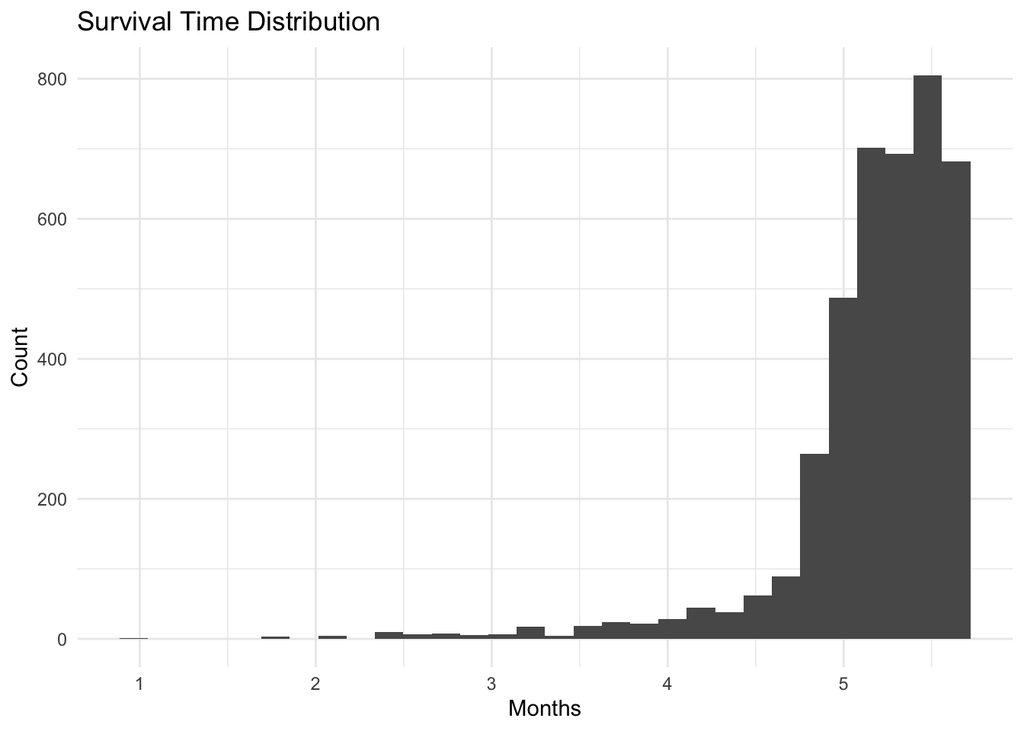

```r
data_clean |> ggplot(aes(x = survival_months, fill = status)) +
  geom_histogram() +
  labs(title = "Survival Time Distribution", x = "Months", y = "Count") +
  theme_minimal()
```

#### Step_3: Variable Description Tables

```r
# Create a data frame for variable descriptions
variable_descriptions <- data.frame(
  Variable = c(
    "Age", "Race", "Marital Status", "T Stage (Tumor)", "N Stage (Node)",
    "Stage (6th Edition)", "Differentiate", "Grade", "A Stage",
    "Tumor Size", "Estrogen Status", "Progesterone Status",
    "Regional Nodes Examined", "Regional Nodes Positive",
    "Survival Months", "Status"
  ),
  Description = c(
    "Patient's age at the time of diagnosis or study enrollment.",
    "Patient's racial identity: Black, White, Other.",
    "Patient's marital status: Married, Single, Divorced, Separated, Widowed.",
    "Tumor size and extent: T1 (≤2 cm), T2 (>2 cm but ≤5 cm), T3 (>5 cm), T4 (invasion into chest wall or skin).",
    "Lymph node involvement: N1 (1–3 nodes), N2 (4–9 nodes), N3 (≥10 nodes).",
    "Overall cancer stage: IIA, IIB, IIIA, IIIB, IIIC.",
    "Tumor differentiation level: Well, Moderately, Poorly, Undifferentiated.",
    "Tumor histological grade: Grade 1 (low), Grade 2 (moderate), Grade 3 (high), Grade IV (anaplastic).",
    "Extent of cancer spread: Regional (local spread), Distant (metastasized).",
    "Size of the tumor in millimeters.",
    "Tumor's estrogen receptor status: Positive, Negative.",
    "Tumor's progesterone receptor status: Positive, Negative.",
    "Number of regional lymph nodes examined for cancer.",
    "Number of regional lymph nodes found to be cancer-positive.",
    "Number of months the patient survived after diagnosis or study enrollment.",
    "Patient's status at the end of the study: Alive, Deceased."
  )
)

# Display the table
kable(variable_descriptions, col.names = c("Variable", "Description"),
      caption = "Variable Descriptions in the Breast Cancer Dataset", align = "l")
```

Variable Descriptions in the Breast Cancer Dataset

| Variable | Description |
| --- | --- |
| Age | Patient’s age at the time of diagnosis or study enrollment. |
| Race | Patient’s racial identity: Black, White, Other. |
| Marital Status | Patient’s marital status: Married, Single, Divorced, Separated, Widowed. |
| T Stage (Tumor) | Tumor size and extent: T1 (≤2 cm), T2 (>2 cm but ≤5 cm), T3 (>5 cm), T4 (invasion into chest wall or skin). |
| N Stage (Node) | Lymph node involvement: N1 (1–3 nodes), N2 (4–9 nodes), N3 (≥10 nodes). |
| Stage (6th Edition) | Overall cancer stage: IIA, IIB, IIIA, IIIB, IIIC. |
| Differentiate | Tumor differentiation level: Well, Moderately, Poorly, Undifferentiated. |
| Grade | Tumor histological grade: Grade 1 (low), Grade 2 (moderate), Grade 3 (high), Grade IV (anaplastic). |
| A Stage | Extent of cancer spread: Regional (local spread), Distant (metastasized). |
| Tumor Size | Size of the tumor in millimeters. |
| Estrogen Status | Tumor’s estrogen receptor status: Positive, Negative. |
| Progesterone Status | Tumor’s progesterone receptor status: Positive, Negative. |
| Regional Nodes Examined | Number of regional lymph nodes examined for cancer. |
| Regional Nodes Positive | Number of regional lymph nodes found to be cancer-positive. |
| Survival Months | Number of months the patient survived after diagnosis or study enrollment. |
| Status | Patient’s status at the end of the study: Alive, Deceased. |

#### Step_4: Visualization for Categorical Variables

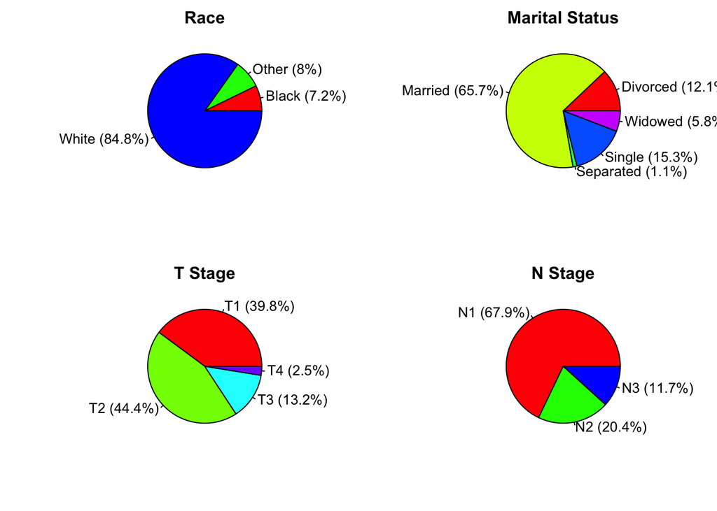

```r
# Ensure variables are converted to factor type
convert_to_factor <- function(data, vars) {
  data %>% mutate(across(all_of(vars), as.factor))
}

# Convert variables to factor type
factor_vars <- c("race", "marital_status", "t_stage", "n_stage",
                 "stage_6th", "differentiate", "grade", "a_stage",
                 "estrogen_status", "progesterone_status", "status")
data_clean <- convert_to_factor(data_clean, factor_vars)

# Define a function to simplify long labels
simplify_labels <- function(label, max_length = 12) {
  ifelse(nchar(label) > max_length, paste0(substr(label, 1, max_length), "..."), label)
}

# Define a function to plot pie charts
plot_pie <- function(data, var, title) {
  counts <- data %>% count(!!sym(var)) %>% mutate(percent = round(n / sum(n) * 100, 1))
  counts <- counts %>% mutate(label = paste0(simplify_labels(as.character(!!sym(var))), " (", percent, "%)"))
  pie_data <- counts$n
  labels <- counts$label
  pie(pie_data, labels = labels, main = title, col = rainbow(length(pie_data)))
}

# Display in multiple pages
# Page 1
par(mfrow = c(2, 2), mar = c(4, 4, 2, 1))
plot_pie(data_clean, "race", "Race")
plot_pie(data_clean, "marital_status", "Marital Status")
plot_pie(data_clean, "t_stage", "T Stage")
plot_pie(data_clean, "n_stage", "N Stage")
```

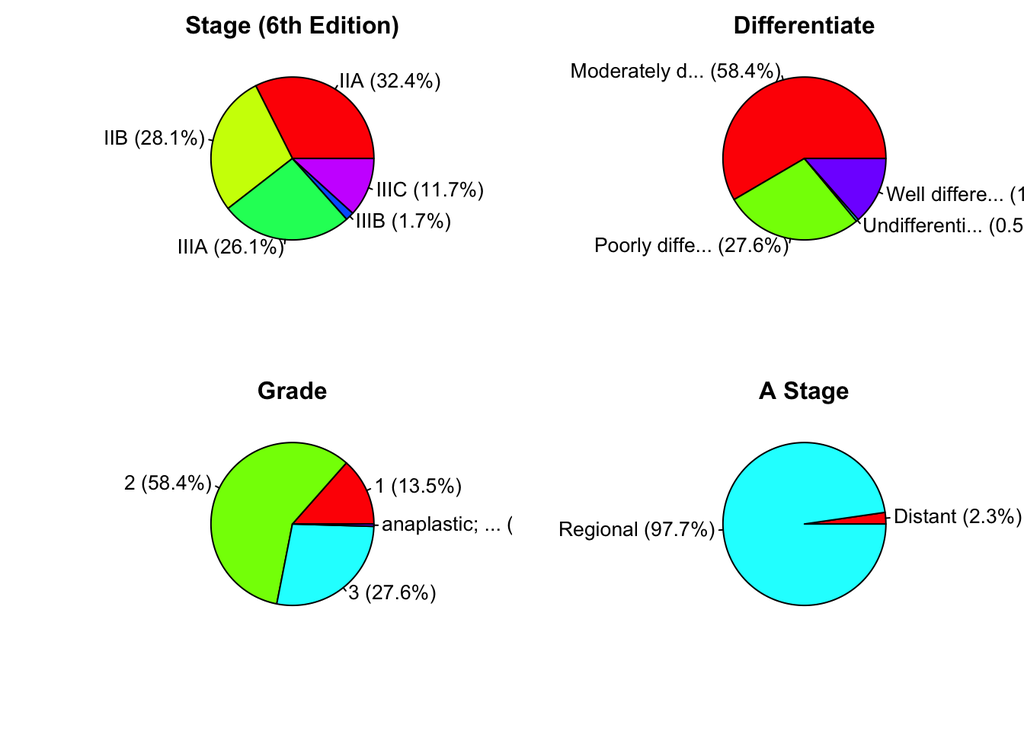

```r
# Page 2
par(mfrow = c(2, 2), mar = c(4, 4, 2, 1))
plot_pie(data_clean, "stage_6th", "Stage (6th Edition)")
plot_pie(data_clean, "differentiate", "Differentiate")
plot_pie(data_clean, "grade", "Grade")
plot_pie(data_clean, "a_stage", "A Stage")
```

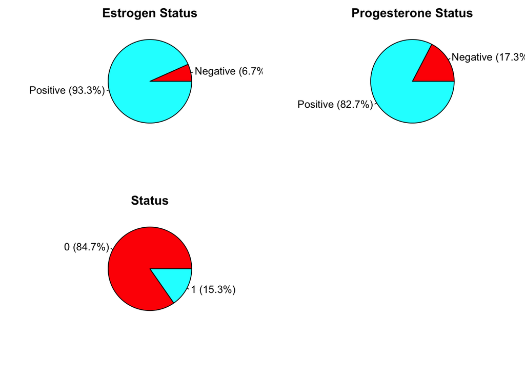

```r
# Page 3
par(mfrow = c(2, 2), mar = c(4, 4, 2, 1))
plot_pie(data_clean, "estrogen_status", "Estrogen Status")
plot_pie(data_clean, "progesterone_status", "Progesterone Status")
plot_pie(data_clean, "status", "Status")
```

#### Step_5: Visualization for Numerical Variables

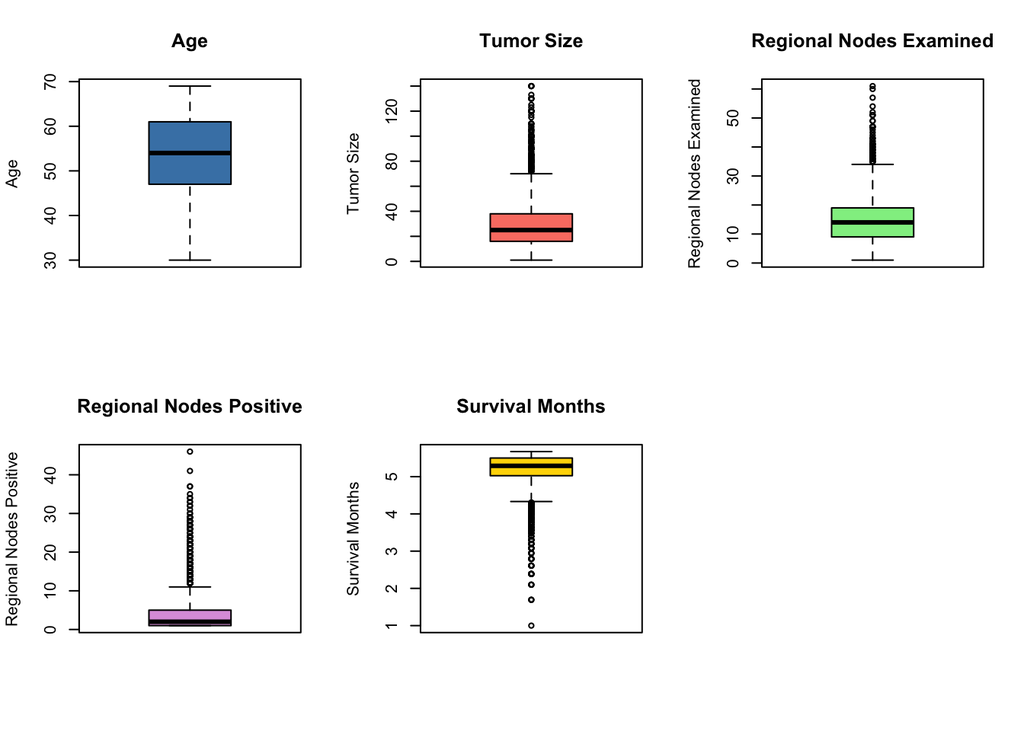

```r
# Select numeric variables and remove missing values
num_vars <- c("age", "tumor_size", "regional_node_examined", "regional_node_positive", "survival_months")

# Use base R to filter the required columns
data_clean_numeric <- data_clean[, num_vars, drop = FALSE]

# Remove rows with missing values
data_clean_numeric <- na.omit(data_clean_numeric)

# Plot boxplots for each numeric variable
par(mfrow = c(2, 3)) # Set layout to 2 rows and 3 columns

boxplot(data_clean_numeric$age,
        main = "Age",
        ylab = "Age",
        col = "steelblue",
        border = "black")

boxplot(data_clean_numeric$tumor_size,
        main = "Tumor Size",
        ylab = "Tumor Size",
        col = "salmon",
        border = "black")

boxplot(data_clean_numeric$regional_node_examined,
        main = "Regional Nodes Examined",
        ylab = "Regional Nodes Examined",
        col = "lightgreen",
        border = "black")

boxplot(data_clean_numeric$regional_node_positive,
        main = "Regional Nodes Positive",
        ylab = "Regional Nodes Positive",
        col = "plum",
        border = "black")

boxplot(data_clean_numeric$survival_months,
        main = "Survival Months",
        ylab = "Survival Months",
        col = "gold",
        border = "black")

# Reset plot parameters to default
par(mfrow = c(1, 1))
```

#### Step_6: Check Multi-collinearity between Different Kinds of Variable

**Checking Multi-Collinearity Among Numerical Variables(Correlation Matrix & Variance Inflation Factor (VIF)) :**

```r
# Select numerical variables
numeric_vars <- data_clean[, c("age", "tumor_size", "regional_node_examined", "regional_node_positive", "survival_months")]

# Correlation matrix
cor_matrix <- cor(numeric_vars, use = "complete.obs")
print(cor_matrix)
```

```
##                                 age  tumor_size regional_node_examined
## age                     1.000000000 -0.07721497            -0.03334548
## tumor_size             -0.077214971  1.00000000             0.10435180
## regional_node_examined -0.033345483  0.10435180             1.00000000
## regional_node_positive  0.012585513  0.24232172             0.41157970
## survival_months        -0.004077672 -0.08317533            -0.01816078
##                        regional_node_positive survival_months
## age                                0.01258551    -0.004077672
## tumor_size                         0.24232172    -0.083175332
## regional_node_examined             0.41157970    -0.018160776
## regional_node_positive             1.00000000    -0.139962706
## survival_months                   -0.13996271     1.000000000
```

```r
# Compute VIF
numeric_model <- lm(survival_months ~ ., data = numeric_vars)
vif_values <- vif(numeric_model)
print(vif_values)
```

```
##                    age             tumor_size regional_node_examined
##               1.008831               1.069709               1.206105
## regional_node_positive
##               1.267895
```

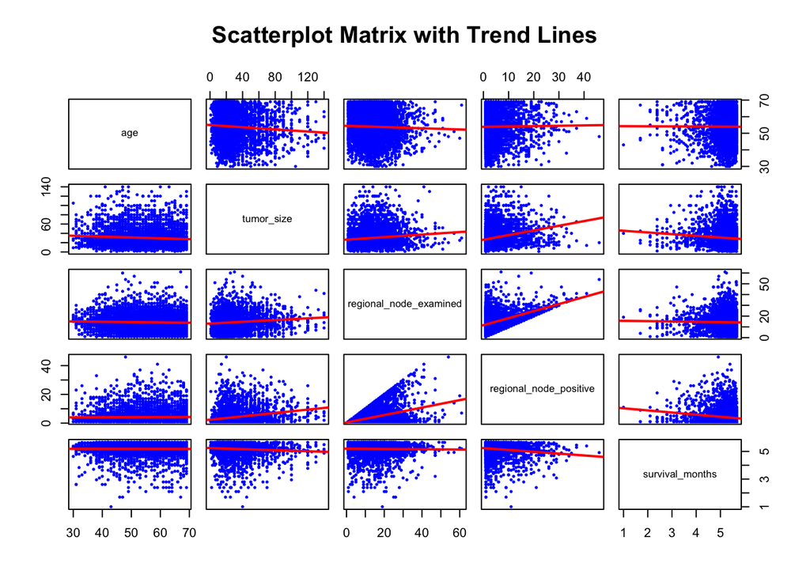

```r
# Select numerical variables (adjust to your dataset)
numerical_vars <- data_clean[, c("age","tumor_size", "regional_node_examined", "regional_node_positive", "survival_months")]

# Create a scatterplot matrix
pairs(
  numerical_vars,
  panel = function(x, y) {
    points(x, y, pch = 20, col = "blue", cex = 0.5)  # Add scatterplot points
    abline(lm(y ~ x), col = "red", lwd = 2)          # Add red trend line
  },
  main = "Scatterplot Matrix with Trend Lines"
)
```

**1. Numerical Variables** - Covariance Matrix: Weak correlations between variables, with the highest at ~0.41 (regional_node_examined and regional_node_positive). - VIF Results: All values <2, indicating no multicollinearity. - Decision: Retain all numerical variables for now, as there are no strong correlations or multicollinearity issues.

**Checking Multi-Collinearity Among Categorical Variables (Chi-Square Test of Independence):**

```r
# Select categorical variables
categorical_vars <- data_clean[, c("race",
                                   "marital_status",
                                   "t_stage",
                                   "n_stage",
                                   "stage_6th",
                                   "differentiate",
                                   "estrogen_status",
                                   "grade",
                                   "a_stage",
                                   "progesterone_status",
                                   "status")]

# Chi-Square or Fisher's Exact Test function with enhancements
perform_chi_square <- function(data, vars) {
  results <- data.frame(Variable1 = character(),
                        Variable2 = character(),
                        Test_Type = character(),
                        Statistic = numeric(),
                        P_Value = numeric())

  for (i in 1:(length(vars) - 1)) {
    for (j in (i + 1):length(vars)) {
      var1 <- vars[i]
      var2 <- vars[j]
      table <- table(data[[var1]], data[[var2]])

      # Check if expected counts are too low for Chi-Square test
      if (any(chisq.test(table, simulate.p.value = TRUE)$expected < 5)) {
        # Use Fisher's Exact Test with Monte Carlo simulation if needed
        test <- fisher.test(table, simulate.p.value = TRUE, B = 10000)
        test_type <- "Fisher's Exact Test (Monte Carlo)"
        statistic <- NA  # Fisher's test does not produce a Chi-Square statistic
      } else {
        # Use Chi-Square Test
        test <- suppressWarnings(chisq.test(table))  # Suppress warnings for small expected counts
        test_type <- "Chi-Square Test"
        statistic <- test$statistic
      }

      # Append results
      results <- rbind(results, data.frame(Variable1 = var1,
                                           Variable2 = var2,
                                           Test_Type = test_type,
                                           Statistic = statistic,
                                           P_Value = test$p.value))
    }
  }

  return(results)
}

# Run the modified function
chi_square_results <- perform_chi_square(data_clean, colnames(categorical_vars))

# Display all results
print(chi_square_results)
```

```
##                       Variable1           Variable2
## 1                          race      marital_status
## X-squared                  race             t_stage
## X-squared1                 race             n_stage
## 11                         race           stage_6th
## 12                         race       differentiate
## X-squared2                 race     estrogen_status
## 13                         race               grade
## X-squared3                 race             a_stage
## X-squared4                 race progesterone_status
## X-squared5                 race              status
## 14               marital_status             t_stage
## X-squared6       marital_status             n_stage
## 15               marital_status           stage_6th
## 16               marital_status       differentiate
## 17               marital_status     estrogen_status
## 18               marital_status               grade
## 19               marital_status             a_stage
## X-squared7       marital_status progesterone_status
## X-squared8       marital_status              status
## X-squared9              t_stage             n_stage
## 110                     t_stage           stage_6th
## 111                     t_stage       differentiate
## X-squared10             t_stage     estrogen_status
## 112                     t_stage               grade
## 113                     t_stage             a_stage
## X-squared11             t_stage progesterone_status
## X-squared12             t_stage              status
## X-squared13             n_stage           stage_6th
## 114                     n_stage       differentiate
## X-squared14             n_stage     estrogen_status
## 115                     n_stage               grade
## X-squared15             n_stage             a_stage
## X-squared16             n_stage progesterone_status
## X-squared17             n_stage              status
## 116                   stage_6th       differentiate
## 117                   stage_6th     estrogen_status
## 118                   stage_6th               grade
## 119                   stage_6th             a_stage
## X-squared18           stage_6th progesterone_status
```

[output cut: 57 more lines]

```
## 120         Fisher's Exact Test (Monte Carlo)           NA  9.999000e-05
## 121         Fisher's Exact Test (Monte Carlo)           NA  9.999000e-05
## 122         Fisher's Exact Test (Monte Carlo)           NA  2.639736e-02
## 123         Fisher's Exact Test (Monte Carlo)           NA  9.999000e-05
## 124         Fisher's Exact Test (Monte Carlo)           NA  9.999000e-05
## 125         Fisher's Exact Test (Monte Carlo)           NA  9.999000e-05
## X-squared20                   Chi-Square Test   15.5892186  7.870207e-05
## X-squared21                   Chi-Square Test 1054.8431237 2.156063e-231
## X-squared22                   Chi-Square Test  135.1557391  3.052608e-31
## 126         Fisher's Exact Test (Monte Carlo)           NA  2.449755e-02
## 127         Fisher's Exact Test (Monte Carlo)           NA  9.999000e-05
## 128         Fisher's Exact Test (Monte Carlo)           NA  9.999000e-05
## X-squared23                   Chi-Square Test    2.3828061  1.226770e-01
## X-squared24                   Chi-Square Test   35.7647266  2.226426e-09
## X-squared25                   Chi-Square Test  124.8853879  5.392080e-29
```

```r
# Filter significant results
significant_results <- chi_square_results %>%
  filter(P_Value < 0.05)

# Print significant results
print("Significant Associations:")
```

```
## [1] "Significant Associations:"
```

```r
print(significant_results)
```

```
##                       Variable1           Variable2
## 1                          race      marital_status
## 12                         race       differentiate
## X-squared2                 race     estrogen_status
## 13                         race               grade
## X-squared5                 race              status
## X-squared6       marital_status             n_stage
## 15               marital_status           stage_6th
## X-squared7       marital_status progesterone_status
## X-squared8       marital_status              status
## X-squared9              t_stage             n_stage
## 110                     t_stage           stage_6th
## 111                     t_stage       differentiate
## X-squared10             t_stage     estrogen_status
## 112                     t_stage               grade
## 113                     t_stage             a_stage
## X-squared11             t_stage progesterone_status
## X-squared12             t_stage              status
## X-squared13             n_stage           stage_6th
## 114                     n_stage       differentiate
## X-squared14             n_stage     estrogen_status
## 115                     n_stage               grade
## X-squared15             n_stage             a_stage
## X-squared16             n_stage progesterone_status
## X-squared17             n_stage              status
## 116                   stage_6th       differentiate
## 117                   stage_6th     estrogen_status
## 118                   stage_6th               grade
## 119                   stage_6th             a_stage
## X-squared18           stage_6th progesterone_status
## X-squared19           stage_6th              status
## 120               differentiate     estrogen_status
## 121               differentiate               grade
## 122               differentiate             a_stage
## 123               differentiate progesterone_status
## 124               differentiate              status
## 125             estrogen_status               grade
## X-squared20     estrogen_status             a_stage
## X-squared21     estrogen_status progesterone_status
## X-squared22     estrogen_status              status
```

[output cut: 35 more lines]

```
## X-squared19                   Chi-Square Test  281.64844  9.830332e-60
## 120         Fisher's Exact Test (Monte Carlo)         NA  9.999000e-05
## 121         Fisher's Exact Test (Monte Carlo)         NA  9.999000e-05
## 122         Fisher's Exact Test (Monte Carlo)         NA  2.639736e-02
## 123         Fisher's Exact Test (Monte Carlo)         NA  9.999000e-05
## 124         Fisher's Exact Test (Monte Carlo)         NA  9.999000e-05
## 125         Fisher's Exact Test (Monte Carlo)         NA  9.999000e-05
## X-squared20                   Chi-Square Test   15.58922  7.870207e-05
## X-squared21                   Chi-Square Test 1054.84312 2.156063e-231
## X-squared22                   Chi-Square Test  135.15574  3.052608e-31
## 126         Fisher's Exact Test (Monte Carlo)         NA  2.449755e-02
## 127         Fisher's Exact Test (Monte Carlo)         NA  9.999000e-05
## 128         Fisher's Exact Test (Monte Carlo)         NA  9.999000e-05
## X-squared24                   Chi-Square Test   35.76473  2.226426e-09
## X-squared25                   Chi-Square Test  124.88539  5.392080e-29
```

**2. Categorical Variables** - Significant Relationships: Key pairs like race and marital_status, t_stage and n_stage, and progesterone_status and status show strong associations (p-value < 0.05). - Decision: Retain all significant categorical variables. Consider redundancy (e.g., between t_stage and n_stage) in further analysis.

**Checking Multi-Collinearity Between Numerical and Categorical Variables (ANOVA):**

```r
perform_anova <- function(data, numeric_vars, categorical_vars) {
  results <- data.frame(Numeric_Var = character(), Categorical_Var = character(), P_Value = numeric())
  for (num_var in numeric_vars) {
    for (cat_var in categorical_vars) {
      formula <- as.formula(paste(num_var, "~", cat_var))
      anova_result <- anova(lm(formula, data = data))
      results <- rbind(results, data.frame(Numeric_Var = num_var, Categorical_Var = cat_var, P_Value = anova_result$`Pr(>F)`[1]))
    }
  }
  results
}

numeric_vars <- c("age", "tumor_size", "regional_node_examined", "regional_node_positive", "survival_months")

categorical_vars <- c("race",
                      "marital_status",
                      "t_stage",
                      "n_stage",
                      'stage_6th',
                      "differentiate",
                      "estrogen_status",
                      "grade",
                      "a_stage",
                      "progesterone_status",
                      "status")

anova_results <- perform_anova(data_clean, numeric_vars, categorical_vars)
print(anova_results)
```

```
##               Numeric_Var     Categorical_Var       P_Value
## 1                     age                race  4.816383e-09
## 2                     age      marital_status  1.991750e-47
## 3                     age             t_stage  2.463390e-05
## 4                     age             n_stage  7.081605e-01
## 5                     age           stage_6th  1.324238e-02
## 6                     age       differentiate  4.884472e-09
## 7                     age     estrogen_status  1.477474e-04
## 8                     age               grade  4.884472e-09
## 9                     age             a_stage  1.858422e-01
## 10                    age progesterone_status  1.773628e-01
## 11                    age              status  3.866328e-04
## 12             tumor_size                race  8.960567e-01
## 13             tumor_size      marital_status  4.779921e-01
## 14             tumor_size             t_stage  0.000000e+00
```

[output cut: 41 more lines]

**3. Numerical × Categorical Interactions (ANOVA Results):** - Significant interactions observed between numerical and categorical variables: - Examples include age with race and t_stage, tumor_size with t_stage and status, and survival_months with status. - Decision: Include key interaction terms like age:t_stage, tumor_size:status, and survival_months:progesterone_status to improve model fit.

#### Step_7: Variable Transformation Section

**For all numerical variables:**

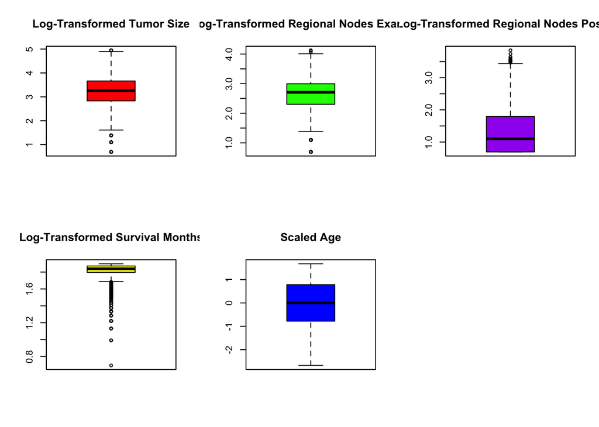

```r
# Visualize current distributions
numerical_vars <- c("age", "tumor_size", "regional_node_examined", "regional_node_positive", "survival_months")

# Apply transformations for skewed variables
data_clean <- data_clean %>%
  mutate(
    # Log transformation for variables with right skewness
    tumor_size_log = log(tumor_size + 1),
    regional_node_examined_log = log(regional_node_examined + 1),
    regional_node_positive_log = log(regional_node_positive + 1),
    survival_months_log = log(survival_months + 1),

    # Scale age (if necessary, based on its distribution)
    age_scaled = scale(age)
  )

# Create box plots for transformed variables
par(mfrow = c(2, 3)) # Set plotting layout
boxplot(data_clean$tumor_size_log, main = "Log-Transformed Tumor Size", col = "red")
boxplot(data_clean$regional_node_examined_log, main = "Log-Transformed Regional Nodes Examined", col = "green")
boxplot(data_clean$regional_node_positive_log, main = "Log-Transformed Regional Nodes Positive", col = "purple")
boxplot(data_clean$survival_months_log, main = "Log-Transformed Survival Months", col = "yellow")
boxplot(data_clean$age_scaled, main = "Scaled Age", col = "blue")
```

**Further improve for survival_months (Box-Cox):**

```r
# Box-Cox transformation
boxcox_result <- boxcox(lm(survival_months ~ 1, data = data_clean), lambda = seq(-2, 2, 0.1))
```

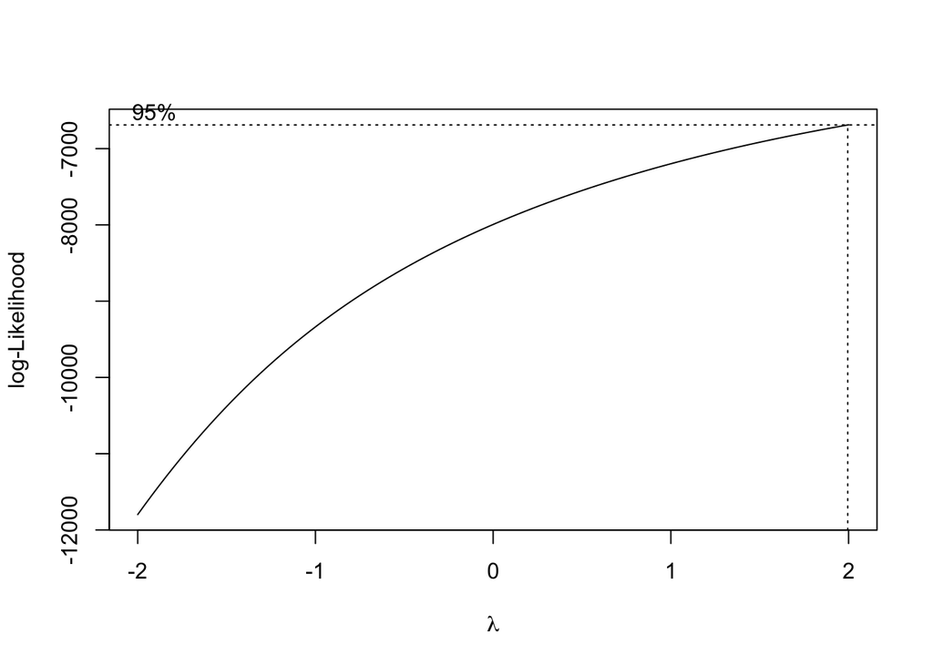

```r
# Find the best lambda
best_lambda <- boxcox_result$x[which.max(boxcox_result$y)]
cat("Best lambda:", best_lambda, "\n")
```

```
## Best lambda: 2
```

```r
# Apply the Box-Cox transformation
data_clean$survival_months_boxcox <- (data_clean$survival_months^best_lambda - 1) / best_lambda

# Check skewness before and after transformation
skewness_before <- skewness(data_clean$survival_months, na.rm = TRUE)
skewness_after <- skewness(data_clean$survival_months_boxcox, na.rm = TRUE)

cat("Skewness Before Transformation:", skewness_before, "\n")
```

```
## Skewness Before Transformation: -2.801215
```

```r
cat("Skewness After Transformation:", skewness_after, "\n")
```

```
## Skewness After Transformation: -1.983729
```

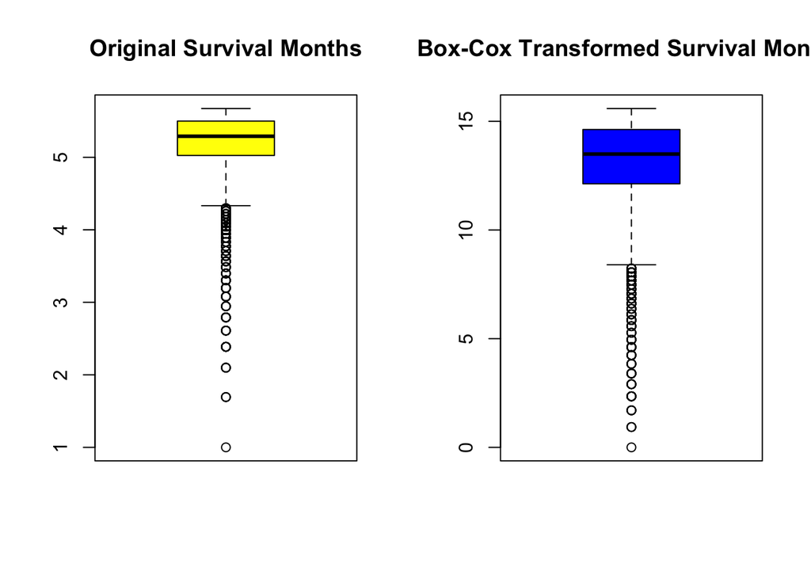

```r
# Boxplot comparison
par(mfrow = c(1, 2))
boxplot(data_clean$survival_months, main = "Original Survival Months", col = "yellow")
boxplot(data_clean$survival_months_boxcox, main = "Box-Cox Transformed Survival Months", col = "blue")
```

#### Step_8: Identifying Influencial Outliers

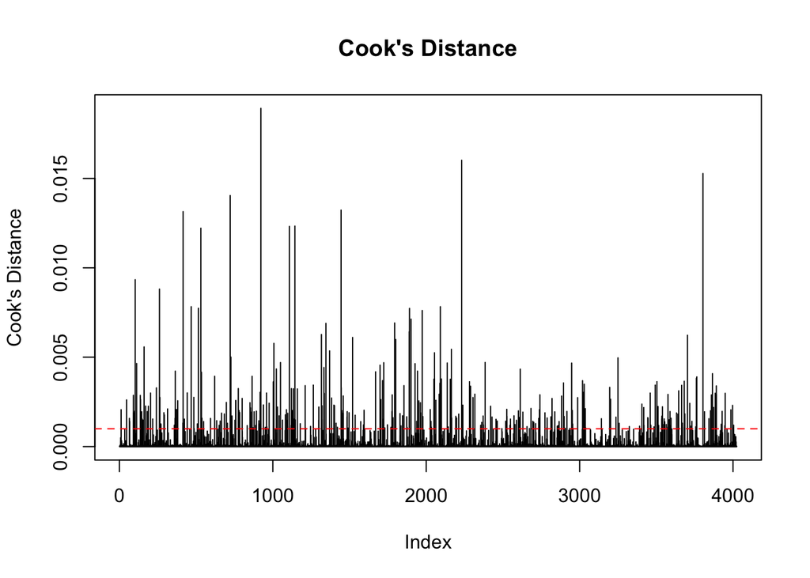

```r
# Ensure your data is clean and transformed (based on previous steps)
data_clean <- data_clean %>%
  mutate(
    survival_months_boxcox = ifelse(is.na(survival_months_boxcox), survival_months, survival_months_boxcox)
  )

# Step 1: Fit a preliminary GLM for death risk prediction
# Assuming "status" is your binary outcome variable (1 = death, 0 = survival)
# Use a logit link function as we are predicting probabilities
glm_model <- glm(status ~ tumor_size_log + regional_node_examined_log + regional_node_positive_log +
                   age_scaled + survival_months_boxcox,
                 data = data_clean,
                 family = binomial(link = "logit"))

# Step 2: Diagnostics for Influential Points
# Leverage values (hat values)
leverage <- hatvalues(glm_model)
# Standardized residuals
std_residuals <- rstandard(glm_model)
# Cook's Distance
cooks_distance <- cooks.distance(glm_model)

# Add diagnostics back to the dataset
data_clean <- data_clean %>%
  mutate(
    leverage = leverage,
    std_residuals = std_residuals,
    cooks_distance = cooks_distance
  )

# Step 3: Visualize Diagnostics
# Set thresholds for diagnostics
leverage_threshold <- 2 * (ncol(data_clean) - 1) / nrow(data_clean) # Rule of thumb
cooks_threshold <- 4 / nrow(data_clean) # Rule of thumb

# Plot Cook's Distance
plot(cooks_distance, type = "h", main = "Cook's Distance", ylab = "Cook's Distance", xlab = "Index")
abline(h = cooks_threshold, col = "red", lty = 2)
```

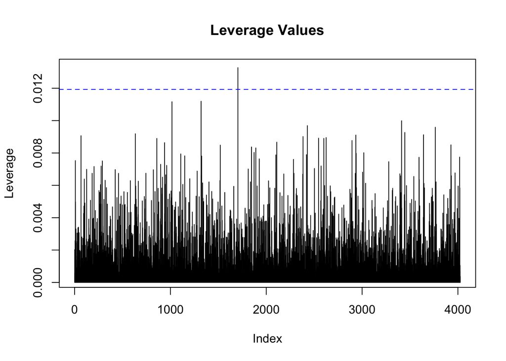

```r
# Plot Leverage
plot(leverage, type = "h", main = "Leverage Values", ylab = "Leverage", xlab = "Index")
abline(h = leverage_threshold, col = "blue", lty = 2)
```

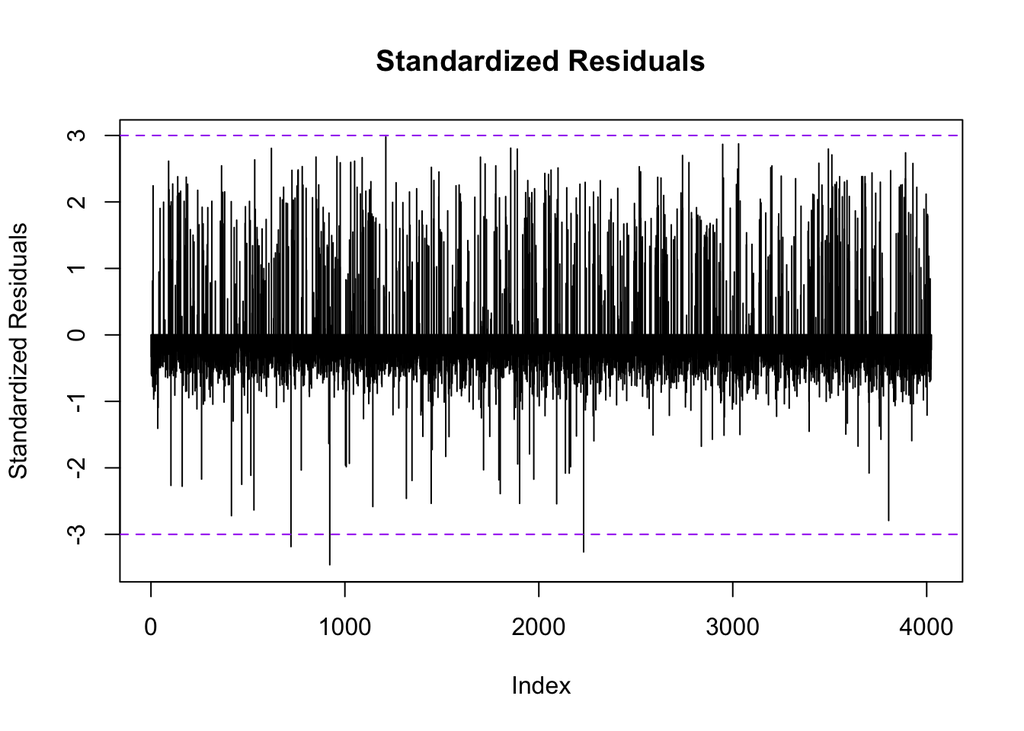

```r
# Plot Standardized Residuals
plot(std_residuals, type = "h", main = "Standardized Residuals", ylab = "Standardized Residuals", xlab = "Index")
abline(h = c(-3, 3), col = "purple", lty = 2)
```

```r
# Step 4: Identify Potential Influential Points
influential_points <- data_clean %>%
  filter(leverage > leverage_threshold | cooks_distance > cooks_threshold | abs(std_residuals) > 3)

# Step 5: Output Influential Points
print("Potential Influential Points:")
```

```
## [1] "Potential Influential Points:"
```

```r
print(influential_points)
```

```
## # A tibble: 331 × 25
##      age race  marital_status t_stage n_stage stage_6th differentiate      grade
##    <dbl> <fct> <fct>          <fct>   <fct>   <fct>     <fct>              <fct>
##  1    68 White Widowed        T1      N1      IIA       Moderately differ… 2
##  2    42 White Married        T1      N3      IIIC      Moderately differ… 2
##  3    67 White Divorced       T1      N1      IIA       Moderately differ… 2
##  4    31 White Married        T3      N3      IIIC      Poorly differenti… 3
##  5    53 White Married        T3      N1      IIIA      Poorly differenti… 3
##  6    63 Other Married        T2      N2      IIIA      Well differentiat… 1
##  7    50 White Married        T4      N1      IIIB      Poorly differenti… 3
##  8    38 White Single         T3      N3      IIIC      Moderately differ… 2
##  9    39 White Married        T2      N1      IIB       Moderately differ… 2
## 10    37 White Married        T3      N1      IIIA      Well differentiat… 1
## # ℹ 321 more rows
## # ℹ 17 more variables: a_stage <fct>, tumor_size <dbl>, estrogen_status <fct>,
## #   progesterone_status <fct>, regional_node_examined <dbl>,
## #   regional_node_positive <dbl>, survival_months <dbl>, status <fct>,
## #   tumor_size_log <dbl>, regional_node_examined_log <dbl>,
## #   regional_node_positive_log <dbl>, survival_months_log <dbl>,
## #   age_scaled <dbl[,1]>, survival_months_boxcox <dbl>, leverage <dbl>, …
```

```r
# Summary
cat("Total influential points detected:", nrow(influential_points), "\n")
```

```
## Total influential points detected: 331
```

The results indicate most data points have minimal impact, but 331 potential influential points warrant further attention. Cook’s Distance, leverage values, and standardized residuals highlight some points that might significantly influence the model. The next steps involve extracting these points, analyzing their distribution and origin, and deciding whether to remove errors or adjust the model to mitigate their impact. Finally, refit the model to ensure robustness.

```r
# Step 6: Investigate Influential Points
# Extract and analyze influential points
influential_points_data <- data_clean %>%
  filter(leverage > leverage_threshold |
         cooks_distance > cooks_threshold |
         abs(std_residuals) > 3)

# View summary of influential points
summary(influential_points_data)
```

```
##       age           race       marital_status t_stage  n_stage  stage_6th
##  Min.   :30.00   Black: 30   Divorced : 43    T1:110   N1:200   IIA :77
##  1st Qu.:45.00   Other: 27   Married  :206    T2:144   N2: 71   IIB :95
##  Median :52.00   White:274   Separated:  6    T3: 58   N3: 60   IIIA:88
##  Mean   :52.91               Single   : 55    T4: 19            IIIB:11
##  3rd Qu.:63.00               Widowed  : 21                      IIIC:60
##  Max.   :69.00
##                    differentiate                  grade         a_stage
##  Moderately differentiated:181   1                   : 30   Distant : 11
##  Poorly differentiated    :118   2                   :181   Regional:320
##  Undifferentiated         :  2   3                   :118
##  Well differentiated      : 30   anaplastic; Grade IV:  2
##
##
##    tumor_size     estrogen_status progesterone_status regional_node_examined
##  Min.   :  1.00   Negative: 32    Negative: 74        Min.   : 1.00
##  1st Qu.: 18.00   Positive:299    Positive:257        1st Qu.: 8.00
##  Median : 25.00                                       Median :14.00
##  Mean   : 34.34                                       Mean   :14.79
##  3rd Qu.: 45.00                                       3rd Qu.:20.50
##  Max.   :140.00                                       Max.   :57.00
##  regional_node_positive survival_months status  tumor_size_log
##  Min.   : 1.000         Min.   :1.000   0: 56   Min.   :0.6931
##  1st Qu.: 1.000         1st Qu.:4.638   1:275   1st Qu.:2.9444
##  Median : 2.000         Median :5.007           Median :3.2581
##  Mean   : 5.341         Mean   :4.822           Mean   :3.3462
##  3rd Qu.: 6.000         3rd Qu.:5.331           3rd Qu.:3.8286
##  Max.   :46.000         Max.   :5.625           Max.   :4.9488
##  regional_node_examined_log regional_node_positive_log survival_months_log
##  Min.   :0.6931             Min.   :0.6931             Min.   :0.6931
##  1st Qu.:2.1972             1st Qu.:0.6931             1st Qu.:1.7295
##  Median :2.7081             Median :1.0986             Median :1.7930
##  Mean   :2.5574             Mean   :1.4735             Mean   :1.7521
##  3rd Qu.:3.0678             3rd Qu.:1.9459             3rd Qu.:1.8454
##  Max.   :4.0604             Max.   :3.8501             Max.   :1.8908
##     age_scaled.V1     survival_months_boxcox    leverage
##  Min.   :-2.6745295   Min.   : 0.00          Min.   :0.0002467
##  1st Qu.:-1.0010077   1st Qu.:10.25          1st Qu.:0.0011756
##  Median :-0.2200310   Median :12.04          Median :0.0023401
##  Mean   :-0.1189118   Mean   :11.39          Mean   :0.0030386
##  3rd Qu.: 1.0072183   3rd Qu.:13.71          3rd Qu.:0.0042786
##  Max.   : 1.6766270   Max.   :15.32          Max.   :0.0132721
##  std_residuals    cooks_distance
##  Min.   :-3.458   Min.   :0.001001
##  1st Qu.: 1.391   1st Qu.:0.001413
##  Median : 1.813   Median :0.001948
##  Mean   : 1.295   Mean   :0.002725
##  3rd Qu.: 2.217   3rd Qu.:0.003001
##  Max.   : 2.977   Max.   :0.018923
```

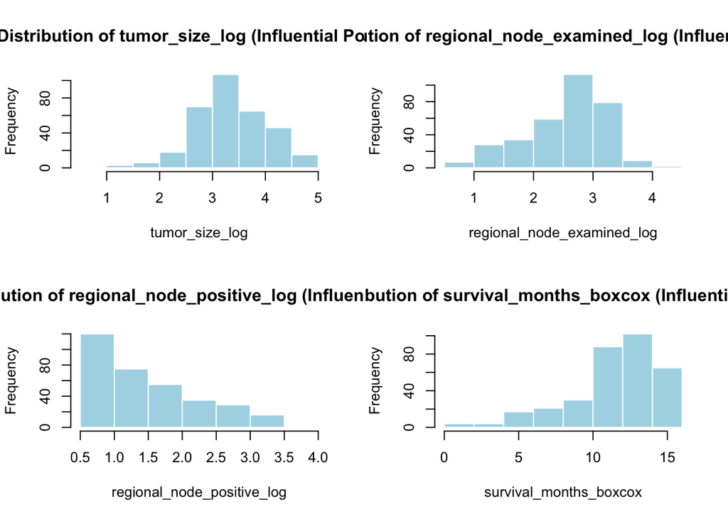

```r
# Visualize distributions for key numeric variables
# Specify the variables of interest
key_numeric_vars <- c("tumor_size_log", "regional_node_examined_log",
                      "regional_node_positive_log", "survival_months_boxcox")

# Set up the plotting layout
par(mfrow = c(2, 2))  # Arrange plots in a 2x2 grid
for (var in key_numeric_vars) {
  if (var %in% colnames(influential_points_data)) {
    hist(influential_points_data[[var]],
         main = paste("Distribution of", var, "(Influential Points)"),
         xlab = var, col = "lightblue", border = "white")
  }
}
```

```r
# Reset plotting layout to default
par(mfrow = c(1, 1))

# Step 7: Handle Influential Points
# Exclude influential points (basic cleaning for modeling preparation)
data_clean_no_outliers <- data_clean %>%
  filter(!(leverage > leverage_threshold |
           cooks_distance > cooks_threshold |
           abs(std_residuals) > 3))

# Refit the GLM model to ensure data is ready for modeling
glm_model_updated <- glm(status ~ tumor_size_log + regional_node_examined_log +
                         regional_node_positive_log + age_scaled +
                         survival_months_boxcox,
                         data = data_clean_no_outliers,
                         family = binomial(link = "logit"))

# Evaluate the updated model
cat("Summary of the updated model:\n")
```

```
## Summary of the updated model:
```

```r
summary(glm_model_updated)
```

```
##
## Call:
## glm(formula = status ~ tumor_size_log + regional_node_examined_log +
##     regional_node_positive_log + age_scaled + survival_months_boxcox,
##     family = binomial(link = "logit"), data = data_clean_no_outliers)
##
## Coefficients:
##                            Estimate Std. Error z value Pr(>|z|)
## (Intercept)                13.50503    1.21919  11.077  < 2e-16 ***
## tumor_size_log              0.62791    0.18550   3.385 0.000712 ***
## regional_node_examined_log -0.71026    0.22420  -3.168 0.001535 **
## regional_node_positive_log  1.82088    0.18275   9.964  < 2e-16 ***
## age_scaled                  0.51745    0.11806   4.383 1.17e-05 ***
## survival_months_boxcox     -1.61551    0.09271 -17.425  < 2e-16 ***
## ---
## Signif. codes:  0 '***' 0.001 '**' 0.01 '*' 0.05 '.' 0.1 ' ' 1
##
## (Dispersion parameter for binomial family taken to be 1)
##
##     Null deviance: 2274.2  on 3692  degrees of freedom
## Residual deviance:  663.3  on 3687  degrees of freedom
## AIC: 675.3
##
## Number of Fisher Scoring iterations: 8
```

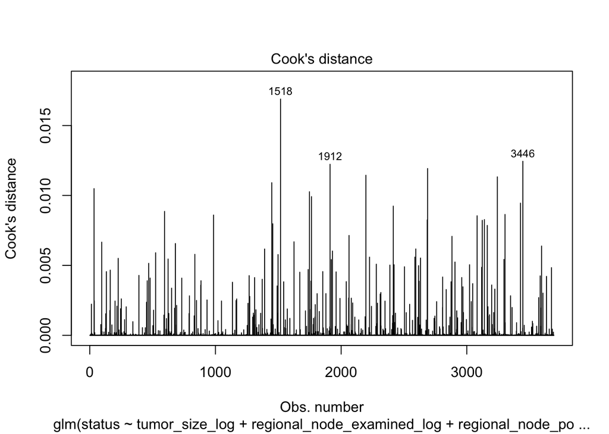

```r
# Diagnostic plots (optional)
plot(glm_model_updated, which = 4)  # Cook's Distance
```

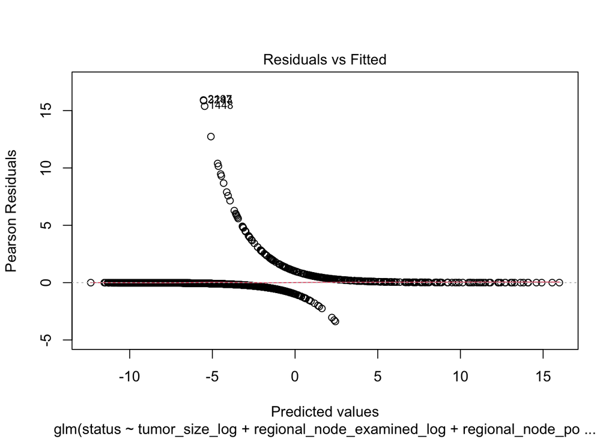

```r
plot(glm_model_updated, which = 1)  # Residuals vs Fitted
```

```r
# Final Message
cat("Process completed. Key numeric variables visualized, updated model fitted, and cleaned dataset saved.\n")
```

```
## Process completed. Key numeric variables visualized, updated model fitted, and cleaned dataset saved.
```

**Comments on Outputs：** - The cleaned model performs well, with all variables being statistically significant. The residual deviance has significantly decreased (663.3), and the AIC value (675.3) indicates a good balance between model fit and complexity. Diagnostic plots confirm that there are no significant high-influence points remaining, and the distributions of key variables are reasonable without severe outliers or biases, demonstrating the effectiveness of the data cleaning process.

**Final Decision：** - We have decided to remove the 300+ influential outliers identified earlier and proceed with the cleaned dataset data_clean_no_outliers as the foundation for modeling. The data quality is sufficient, marking the conclusion of the data exploration phase and the transition to the modeling stage.

### II. Modeling

#### Step_1: Logistic Regression Model with Interaction Terms and Optimization

```r
# Ensure data balance
# Split data based on status
data_majority <- data_clean_no_outliers %>% filter(status == 0)
data_minority <- data_clean_no_outliers %>% filter(status == 1)
set.seed(123)
data_majority_sample <- data_majority %>% sample_n(min(nrow(data_minority) * 2, nrow(data_majority)))
data_balanced <- bind_rows(data_majority_sample, data_minority)

# Standardize numerical variables
data_balanced$tumor_size_log <- scale(data_balanced$tumor_size_log)
data_balanced$regional_node_examined_log <- scale(data_balanced$regional_node_examined_log)
data_balanced$regional_node_positive_log <- scale(data_balanced$regional_node_positive_log)
data_balanced$survival_months_boxcox <- scale(data_balanced$survival_months_boxcox)
data_balanced$age_scaled <- scale(data_balanced$age_scaled)

# Split data into training and testing sets
set.seed(123)
trainIndex <- createDataPartition(data_balanced$status, p = 0.8, list = FALSE)
train_data <- data_balanced[trainIndex, ]
test_data <- data_balanced[-trainIndex, ]

# Prepare training data for Lasso regression
x_train <- model.matrix(status ~ tumor_size_log + regional_node_examined_log +
                        regional_node_positive_log + survival_months_boxcox +
                        age_scaled + race + marital_status + t_stage + n_stage +
                        stage_6th + differentiate + estrogen_status + grade +
                        a_stage + progesterone_status + age_scaled:t_stage +
                        tumor_size_log:status + survival_months_boxcox:progesterone_status,
                        data = train_data)[, -1]
y_train <- train_data$status

# Perform Lasso regression
lasso_model <- cv.glmnet(x_train, y_train, alpha = 1, family = "binomial")
best_lambda <- lasso_model$lambda.min
model_lasso <- glmnet(x_train, y_train, alpha = 1, lambda = best_lambda, family = "binomial")

# Extract coefficients from the Lasso model
coef_lasso <- coef(model_lasso, s = best_lambda)
selected_variables_df <- as.data.frame(as.matrix(coef_lasso))
colnames(selected_variables_df) <- "Coefficient"
selected_variables_df <- selected_variables_df[selected_variables_df$Coefficient != 0, , drop = FALSE]
selected_variables_df <- cbind(Variable = rownames(selected_variables_df), selected_variables_df)
rownames(selected_variables_df) <- NULL
print("Selected variables by Lasso model:")
```

```
## [1] "Selected variables by Lasso model:"
```

```r
# Present coefficients in a table format
knitr::kable(selected_variables_df, caption = "Coefficients of the Optimal Lasso Model")
```

Coefficients of the Optimal Lasso Model

| Variable | Coefficient |
| --- | --- |
| (Intercept) | -1.1126229 |
| regional_node_examined_log | -0.2127777 |
| regional_node_positive_log | 1.2289846 |
| survival_months_boxcox | -4.2650954 |
| age_scaled | 0.1765491 |
| raceOther | -1.7033045 |
| raceWhite | -0.5564617 |
| marital_statusSingle | -0.0955304 |
| marital_statusWidowed | -0.0098700 |
| t_stageT2 | 0.9403077 |
| n_stageN3 | 0.0913812 |
| stage_6thIIIC | 0.0514802 |
| differentiatePoorly differentiated | 0.6297549 |
| differentiateUndifferentiated | 3.3406388 |
| differentiateWell differentiated | -0.1250715 |
| estrogen_statusPositive | 0.1671107 |
| grade3 | 0.0239706 |
| gradeanaplastic; Grade IV | 0.0118946 |
| progesterone_statusPositive | -0.6840958 |
| age_scaled:t_stageT4 | 0.1264922 |
| status1:tumor_size_log | 0.5409229 |

```r
# Validate the model on the testing set
x_test <- model.matrix(status ~ tumor_size_log + regional_node_examined_log +
                       regional_node_positive_log + survival_months_boxcox +
                       age_scaled + race + marital_status + t_stage + n_stage +
                       stage_6th + differentiate + estrogen_status + grade +
                       a_stage + progesterone_status + age_scaled:t_stage +
                       tumor_size_log:status + survival_months_boxcox:progesterone_status,
                       data = test_data)[, -1]
y_test <- test_data$status
test_predictions <- as.numeric(predict(model_lasso, newx = x_test, type = "response"))

# Calculate AUC on the testing set
roc_curve_test <- roc(y_test, test_predictions)
auc_test <- auc(roc_curve_test)
print(paste("Test AUC:", auc_test))
```

```
## [1] "Test AUC: 0.990808823529412"
```

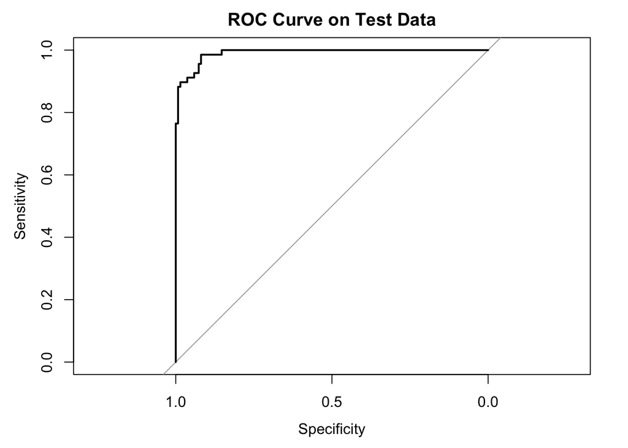

```r
plot(roc_curve_test, main = "ROC Curve on Test Data")
```

```r
# Calculate AUC on the training set
train_predictions <- as.numeric(predict(model_lasso, newx = x_train, type = "response"))
roc_curve_train <- roc(y_train, train_predictions)
auc_train <- auc(roc_curve_train)
print(paste("Train AUC:", auc_train))
```

```
## [1] "Train AUC: 0.980329804505626"
```

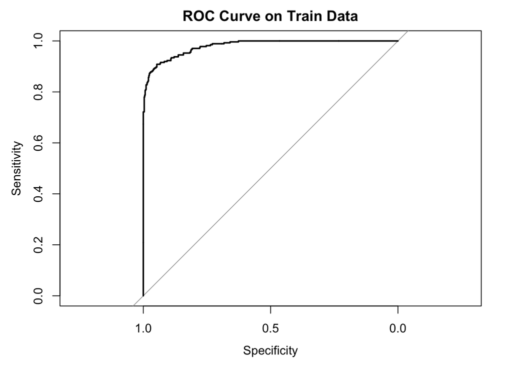

```r
plot(roc_curve_train, main = "ROC Curve on Train Data")
```

#### Step_2: Cox Proportional Hazards Model

```r
# Data preparation
cox_data <- data_clean_no_outliers
cox_data$status <- as.numeric(cox_data$status)  # Cox model requires status to be numeric (0: alive, 1: dead)

# Define the Cox model formula, including main effects and interaction terms
cox_formula <- as.formula("Surv(survival_months_boxcox, status) ~
                           tumor_size_log + regional_node_examined_log +
                           regional_node_positive_log + age_scaled + race +
                           marital_status + t_stage + n_stage + stage_6th +
                           differentiate + estrogen_status + grade + a_stage +
                           progesterone_status + age_scaled:t_stage +
                           tumor_size_log:status + survival_months_boxcox:progesterone_status")

# Fit the Cox proportional hazards model
cox_model <- coxph(cox_formula, data = cox_data)
# Output model results
summary(cox_model)
```

```
## Call:
## coxph(formula = cox_formula, data = cox_data)
##
##   n= 3693, number of events= 341
##
##                                                          coef  exp(coef)
## tumor_size_log                                     -8.986e+00  1.251e-04
## regional_node_examined_log                         -4.719e-05  1.000e+00
## regional_node_positive_log                          4.788e-04  1.000e+00
## age_scaled                                          1.748e-03  1.002e+00
## raceOther                                           3.291e-03  1.003e+00
## raceWhite                                           4.189e-03  1.004e+00
## marital_statusMarried                               8.754e-04  1.001e+00
## marital_statusSeparated                            -6.155e-05  9.999e-01
## marital_statusSingle                                1.460e-03  1.001e+00
## marital_statusWidowed                               2.276e-03  1.002e+00
## t_stageT2                                          -1.013e-02  9.899e-01
## t_stageT3                                          -1.818e-02  9.820e-01
## t_stageT4                                          -1.025e-02  9.898e-01
## n_stageN2                                           2.137e-03  1.002e+00
## n_stageN3                                           3.567e-03  1.004e+00
## stage_6thIIB                                        7.061e-03  1.007e+00
## stage_6thIIIA                                       3.266e-03  1.003e+00
## stage_6thIIIB                                      -3.941e-03  9.961e-01
## stage_6thIIIC                                       0.000e+00  1.000e+00
## differentiatePoorly differentiated                  2.106e-03  1.002e+00
## differentiateUndifferentiated                      -7.354e-04  9.993e-01
## differentiateWell differentiated                    4.621e-03  1.005e+00
## estrogen_statusPositive                             3.077e-03  1.003e+00
## grade2                                              0.000e+00  1.000e+00
## grade3                                              0.000e+00  1.000e+00
## gradeanaplastic; Grade IV                           0.000e+00  1.000e+00
## a_stageRegional                                     9.840e-04  1.001e+00
## progesterone_statusPositive                        -2.068e-03  9.979e-01
## age_scaled:t_stageT2                               -2.288e-03  9.977e-01
## age_scaled:t_stageT3                               -3.805e-03  9.962e-01
## age_scaled:t_stageT4                               -4.166e-03  9.958e-01
## tumor_size_log:status                               4.500e+00  9.001e+01
## progesterone_statusNegative:survival_months_boxcox -5.528e+01  9.867e-25
## progesterone_statusPositive:survival_months_boxcox -5.528e+01  9.867e-25
```

[output cut: 133 more lines]

```
## grade3                                             7.836e-01 1.276e+00
## gradeanaplastic; Grade IV                          4.157e-01 2.405e+00
## a_stageRegional                                    6.365e-01 1.574e+00
## progesterone_statusPositive                        7.783e-01 1.280e+00
## age_scaled:t_stageT2                               8.430e-01 1.181e+00
## age_scaled:t_stageT3                               7.515e-01 1.321e+00
## age_scaled:t_stageT4                               6.560e-01 1.512e+00
## tumor_size_log:status                              8.120e+01 9.978e+01
## progesterone_statusNegative:survival_months_boxcox 9.597e-25 1.014e-24
## progesterone_statusPositive:survival_months_boxcox 9.598e-25 1.014e-24
##
## Concordance= 1  (se = 0 )
## Likelihood ratio test= 4792  on 34 df,   p=<2e-16
## Wald test            = 30719868  on 34 df,   p=<2e-16
## Score (logrank) test = 7602  on 34 df,   p=<2e-16
```

```r
# Check model performance - calculate C-index
cindex <- summary(cox_model)$concordance[1]
print(paste("C-index:", cindex))
```

```
## [1] "C-index: 1"
```

```r
# Compare model prediction performance
# Predictions from the logistic model (assuming test_predictions are generated)
roc_logistic <- roc(y_test, test_predictions)
auc_logistic <- auc(roc_logistic)
print(paste("Logistic Test AUC:", auc_logistic))
```

```
## [1] "Logistic Test AUC: 0.990808823529412"
```

```r
# Risk scores from the Cox model
cox_risk <- predict(cox_model, type = "risk")
roc_cox <- roc(cox_data$status, cox_risk)
auc_cox <- auc(roc_cox)
print(paste("Cox Model AUC:", auc_cox))
```

```
## [1] "Cox Model AUC: 0.970237053730773"
```

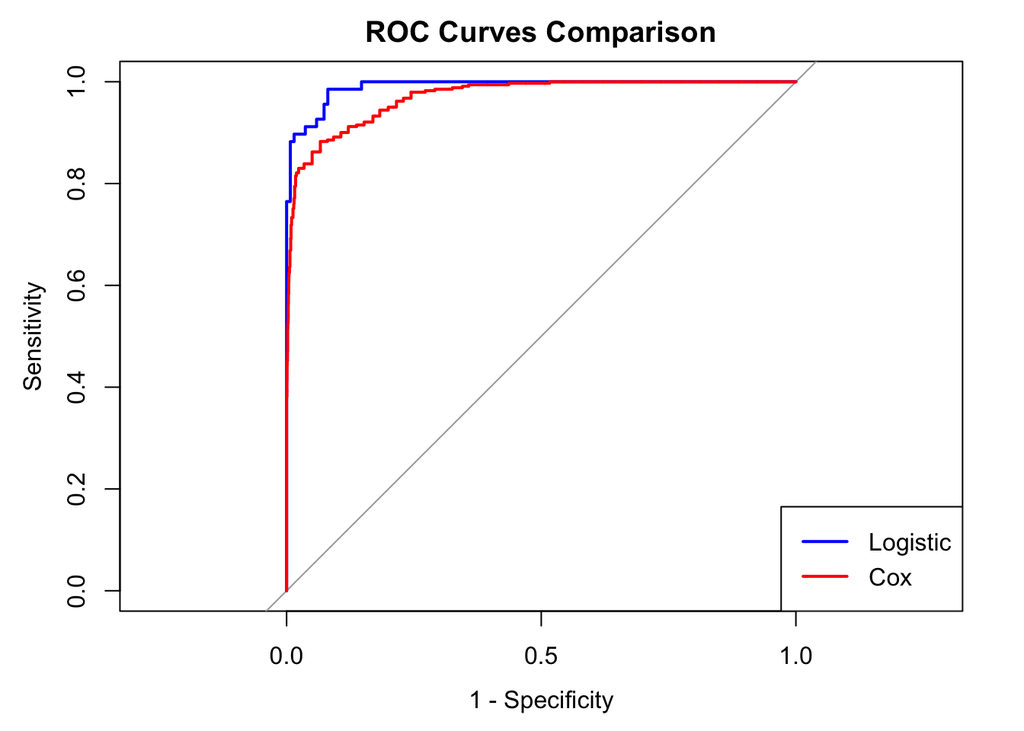

```r
# Output ROC curve comparison
plot(roc_logistic, main = "ROC Curves Comparison", col = "blue", legacy.axes = TRUE)
lines(roc_cox, col = "red")
legend("bottomright", legend = c("Logistic", "Cox"), col = c("blue", "red"), lwd = 2)
```

```r
# Extract coefficients from the Cox model
cox_summary <- summary(cox_model)
coefficients <- as.data.frame(cox_summary$coefficients)
colnames(coefficients) <- c("Coefficient", "Exp(Coefficient)", "Standard Error", "z-value", "p-value")

# Create and visualize the table for all coefficients
coefficients_table <- coefficients %>%
  rownames_to_column(var = "Variable") %>%
  kable("html", caption = "Cox Model Coefficients") %>%
  kable_styling(bootstrap_options = c("striped", "hover", "condensed", "responsive"), full_width = FALSE)

# Show the table for all coefficients
coefficients_table
```

Cox Model Coefficients

| Variable | Coefficient | Exp(Coefficient) | Standard Error | z-value | p-value |
| --- | --- | --- | --- | --- | --- |
| tumor_size_log | -8.9862884 | 0.0001251 | 0.1054954 | -85.1817826 | 0.0000000 |
| regional_node_examined_log | -0.0000472 | 0.9999528 | 0.1085778 | -0.0004346 | 0.9996532 |
| regional_node_positive_log | 0.0004788 | 1.0004789 | 0.0785832 | 0.0060927 | 0.9951387 |
| age_scaled | 0.0017484 | 1.0017499 | 0.0633788 | 0.0275863 | 0.9779921 |
| raceOther | 0.0032910 | 1.0032964 | 0.2963668 | 0.0111045 | 0.9911401 |
| raceWhite | 0.0041888 | 1.0041975 | 0.1608252 | 0.0260455 | 0.9792211 |
| marital_statusMarried | 0.0008754 | 1.0008758 | 0.1209759 | 0.0072363 | 0.9942263 |
| marital_statusSeparated | -0.0000615 | 0.9999385 | 0.3516405 | -0.0001750 | 0.9998603 |
| marital_statusSingle | 0.0014597 | 1.0014607 | 0.1607326 | 0.0090813 | 0.9927542 |
| marital_statusWidowed | 0.0022764 | 1.0022790 | 0.2098098 | 0.0108499 | 0.9913432 |
| t_stageT2 | -0.0101315 | 0.9899197 | 0.1220186 | -0.0830320 | 0.9338261 |
| t_stageT3 | -0.0181759 | 0.9819883 | 0.1521144 | -0.1194885 | 0.9048884 |
| t_stageT4 | -0.0102453 | 0.9898070 | 0.2438168 | -0.0420204 | 0.9664824 |
| n_stageN2 | 0.0021370 | 1.0021393 | 0.1292166 | 0.0165380 | 0.9868052 |
| n_stageN3 | 0.0035670 | 1.0035733 | 0.1236519 | 0.0288468 | 0.9769868 |
| stage_6thIIB | 0.0070613 | 1.0070863 | 0.1598149 | 0.0441841 | 0.9647577 |
| stage_6thIIIA | 0.0032658 | 1.0032712 | 0.1269499 | 0.0257255 | 0.9794763 |
| stage_6thIIIB | -0.0039414 | 0.9960664 | 0.3785811 | -0.0104109 | 0.9916934 |
| stage_6thIIIC | 0.0000000 | 1.0000000 | 0.1236519 | 0.0000000 | 1.0000000 |
| differentiatePoorly differentiated | 0.0021058 | 1.0021080 | 0.1244206 | 0.0169247 | 0.9864967 |
| differentiateUndifferentiated | -0.0007354 | 0.9992649 | 0.4477999 | -0.0016422 | 0.9986897 |
| differentiateWell differentiated | 0.0046211 | 1.0046318 | 0.2791066 | 0.0165569 | 0.9867901 |
| estrogen_statusPositive | 0.0030773 | 1.0030820 | 0.1520626 | 0.0202371 | 0.9838542 |
| grade2 | 0.0000000 | 1.0000000 | 0.1258793 | 0.0000000 | 1.0000000 |
| grade3 | 0.0000000 | 1.0000000 | 0.1244206 | 0.0000000 | 1.0000000 |
| gradeanaplastic; Grade IV | 0.0000000 | 1.0000000 | 0.4477999 | 0.0000000 | 1.0000000 |
| a_stageRegional | 0.0009840 | 1.0009845 | 0.2310265 | 0.0042594 | 0.9966015 |
| progesterone_statusPositive | -0.0020682 | 0.9979340 | 0.1268311 | -0.0163065 | 0.9869898 |
| age_scaled:t_stageT2 | -0.0022880 | 0.9977146 | 0.0859432 | -0.0266223 | 0.9787610 |
| age_scaled:t_stageT3 | -0.0038048 | 0.9962025 | 0.1438325 | -0.0264527 | 0.9788963 |
| age_scaled:t_stageT4 | -0.0041662 | 0.9958425 | 0.2129544 | -0.0195637 | 0.9843914 |
| tumor_size_log:status | 4.4999286 | 90.0107010 | 0.0525902 | 85.5659521 | 0.0000000 |
| progesterone_statusNegative:survival_months_boxcox | -55.2754780 | 0.0000000 | 0.0141072 | -3918.2418706 | 0.0000000 |
| progesterone_statusPositive:survival_months_boxcox | -55.2754619 | 0.0000000 | 0.0141072 | -3918.2484653 | 0.0000000 |

```r
# Create and visualize the table for significant coefficients (p-value < 0.05)
significant_coefficients <- coefficients %>%
  filter(`p-value` < 0.05) %>%
  rownames_to_column(var = "Variable") %>%
  kable("html", caption = "Significant Cox Model Coefficients") %>%
  kable_styling(bootstrap_options = c("striped", "hover", "condensed", "responsive"), full_width = FALSE)

# Show the table for significant coefficients
significant_coefficients
```

Significant Cox Model Coefficients

| Variable | Coefficient | Exp(Coefficient) | Standard Error | z-value | p-value |
| --- | --- | --- | --- | --- | --- |
| tumor_size_log | -8.986288 | 0.0001251 | 0.1054954 | -85.18178 | 0 |
| tumor_size_log:status | 4.499929 | 90.0107010 | 0.0525902 | 85.56595 | 0 |
| progesterone_statusNegative:survival_months_boxcox | -55.275478 | 0.0000000 | 0.0141072 | -3918.24187 | 0 |
| progesterone_statusPositive:survival_months_boxcox | -55.275462 | 0.0000000 | 0.0141072 | -3918.24847 | 0 |

#### Step_4: Model Fairness Evaluation

```r
# Calculate model performance for different racial groups
# Logistic model - Compute AUC by race
roc_logistic_white <- roc(
  test_data %>% filter(race == "White") %>% pull(status),
  test_predictions[test_data$race == "White"]
)
roc_logistic_black <- roc(
  test_data %>% filter(race == "Black") %>% pull(status),
  test_predictions[test_data$race == "Black"]
)
# Output AUC
auc_logistic_white <- auc(roc_logistic_white)
auc_logistic_black <- auc(roc_logistic_black)

print(paste("Logistic Test AUC for White:", auc_logistic_white))
```

```
## [1] "Logistic Test AUC for White: 0.99040404040404"
```

```r
print(paste("Logistic Test AUC for Black:", auc_logistic_black))
```

```
## [1] "Logistic Test AUC for Black: 0.982142857142857"
```

```r
# Cox model - Compute AUC by race
cox_risk_white <- predict(
  cox_model,
  newdata = cox_data %>% filter(race == "White"),
  type = "risk"
)
cox_risk_black <- predict(
  cox_model,
  newdata = cox_data %>% filter(race == "Black"),
  type = "risk"
)

# ROC curve - White group
roc_cox_white <- roc(
  cox_data %>% filter(race == "White") %>% pull(status),
  cox_risk_white
)
# ROC curve - Black group
roc_cox_black <- roc(
  cox_data %>% filter(race == "Black") %>% pull(status),
  cox_risk_black
)
# Output AUC
auc_cox_white <- auc(roc_cox_white)
auc_cox_black <- auc(roc_cox_black)

print(paste("Cox Model AUC for White:", auc_cox_white))
```

```
## [1] "Cox Model AUC for White: 0.971583791766396"
```

```r
print(paste("Cox Model AUC for Black:", auc_cox_black))
```

```
## [1] "Cox Model AUC for Black: 0.965419615773507"
```

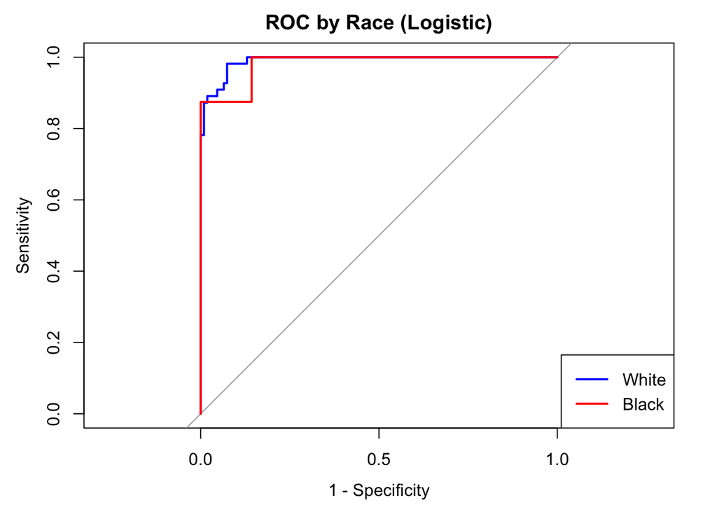

```r
# Plot ROC curves by race for Logistic model
plot(roc_logistic_white, col = "blue", legacy.axes = TRUE, main = "ROC by Race (Logistic)")
lines(roc_logistic_black, col = "red")
legend("bottomright", legend = c("White", "Black"), col = c("blue", "red"), lwd = 2)
```

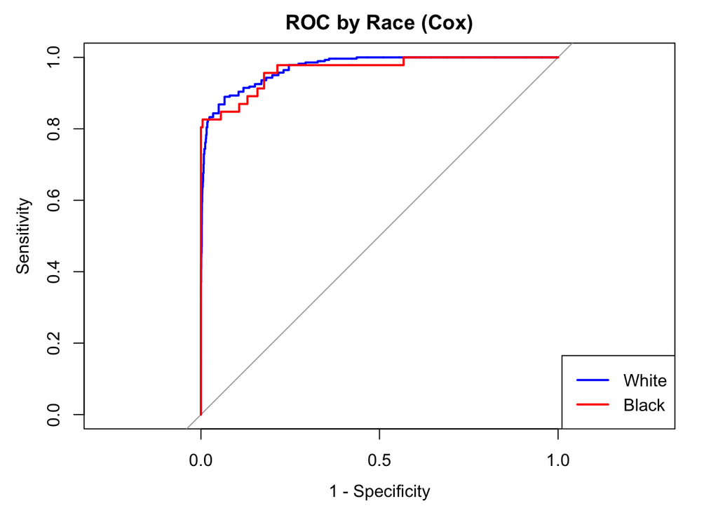

```r
# Plot ROC curves by race for Cox model
plot(roc_cox_white, col = "blue", legacy.axes = TRUE, main = "ROC by Race (Cox)")
lines(roc_cox_black, col = "red")
legend("bottomright", legend = c("White", "Black"), col = c("blue", "red"), lwd = 2)
```

**Comments_1:** - The figures demonstrate the predictive performance of Logistic and Cox models across racial groups (White and Black). For the Logistic model, the AUC is 0.9904 for the White group and 0.9821 for the Black group. For the Cox model, the AUC is 0.9716 for the White group and 0.9654 for the Black group. In the ROC curves, the White group’s curve slightly outperforms the Black group’s curve, indicating a minor performance difference.

**Comments_2:** - Both the Logistic and Cox models exhibit high predictive performance across racial groups, with slightly better results for the White group compared to the Black group, indicating minor unfairness. Although the differences are small, the potential bias against minority groups should be addressed, and further optimization is recommended to enhance fairness.

#### Step_5: Model Feature Importance Evaluation

```r
# Convert sparse matrix to a regular matrix
lasso_importance <- as.matrix(abs(coef_lasso))

# Convert matrix to a data frame
lasso_importance <- as.data.frame(lasso_importance)

# Add variable names as a column
lasso_importance$Variable <- rownames(lasso_importance)

# Rename columns for clarity
colnames(lasso_importance) <- c("Importance", "Variable")

# Reorder by importance
lasso_importance <- lasso_importance[order(-lasso_importance$Importance), ]

# Display the feature importance table
knitr::kable(lasso_importance, caption = "Feature Importance for Logistic Model")
```

Feature Importance for Logistic Model

|  | Importance | Variable |
| --- | --- | --- |
| survival_months_boxcox | 4.2650954 | survival_months_boxcox |
| differentiateUndifferentiated | 3.3406388 | differentiateUndifferentiated |
| raceOther | 1.7033045 | raceOther |
| regional_node_positive_log | 1.2289846 | regional_node_positive_log |
| (Intercept) | 1.1126229 | (Intercept) |
| t_stageT2 | 0.9403077 | t_stageT2 |
| progesterone_statusPositive | 0.6840958 | progesterone_statusPositive |
| differentiatePoorly differentiated | 0.6297549 | differentiatePoorly differentiated |
| raceWhite | 0.5564617 | raceWhite |
| status1:tumor_size_log | 0.5409229 | status1:tumor_size_log |
| regional_node_examined_log | 0.2127777 | regional_node_examined_log |
| age_scaled | 0.1765491 | age_scaled |
| estrogen_statusPositive | 0.1671107 | estrogen_statusPositive |
| age_scaled:t_stageT4 | 0.1264922 | age_scaled:t_stageT4 |
| differentiateWell differentiated | 0.1250715 | differentiateWell differentiated |
| marital_statusSingle | 0.0955304 | marital_statusSingle |
| n_stageN3 | 0.0913812 | n_stageN3 |
| stage_6thIIIC | 0.0514802 | stage_6thIIIC |
| grade3 | 0.0239706 | grade3 |
| gradeanaplastic; Grade IV | 0.0118946 | gradeanaplastic; Grade IV |
| marital_statusWidowed | 0.0098700 | marital_statusWidowed |
| tumor_size_log | 0.0000000 | tumor_size_log |
| marital_statusMarried | 0.0000000 | marital_statusMarried |
| marital_statusSeparated | 0.0000000 | marital_statusSeparated |
| t_stageT3 | 0.0000000 | t_stageT3 |
| t_stageT4 | 0.0000000 | t_stageT4 |
| n_stageN2 | 0.0000000 | n_stageN2 |
| stage_6thIIB | 0.0000000 | stage_6thIIB |
| stage_6thIIIA | 0.0000000 | stage_6thIIIA |
| stage_6thIIIB | 0.0000000 | stage_6thIIIB |
| grade2 | 0.0000000 | grade2 |
| a_stageRegional | 0.0000000 | a_stageRegional |
| age_scaled:t_stageT2 | 0.0000000 | age_scaled:t_stageT2 |
| age_scaled:t_stageT3 | 0.0000000 | age_scaled:t_stageT3 |
| survival_months_boxcox:progesterone_statusPositive | 0.0000000 | survival_months_boxcox:progesterone_statusPositive |

#### Step_6: Model Calibration and Diagnostics

**Part_1: COX**

```r
# Step 1: Check numeric variables for zero variance
print("Checking numeric variables for zero variance:")
```

```
## [1] "Checking numeric variables for zero variance:"
```

```r
zero_variance_vars <- apply(cox_data, 2, function(x) if (is.numeric(x)) var(x, na.rm = TRUE) == 0)
print("Variables with zero variance:")
```

```
## [1] "Variables with zero variance:"
```

```r
print(names(zero_variance_vars[zero_variance_vars]))
```

[output not shown]

```r
# Step 2: Check categorical variables for sparse levels
print("Checking categorical variables for sparse levels:")
```

```
## [1] "Checking categorical variables for sparse levels:"
```

```r
sparse_levels <- lapply(cox_data, function(x) if (is.factor(x)) table(x))
print("Sparse levels in categorical variables:")
```

```
## [1] "Sparse levels in categorical variables:"
```

```r
print(sparse_levels)
```

```
## $age
## NULL
##
## $race
## x
## Black Other White
##   261   293  3139
##
## $marital_status
## x
##  Divorced   Married Separated    Single   Widowed
##       443      2437        39       560       214
##
## $t_stage
## x
##   T1   T2   T3   T4
## 1493 1642  475   83
##
## $n_stage
## x
##   N1   N2   N3
## 2532  749  412
##
## $stage_6th
## x
##  IIA  IIB IIIA IIIB IIIC
## 1228 1035  962   56  412
##
## $differentiate
## x
## Moderately differentiated     Poorly differentiated          Undifferentiated
##                      2170                       993                        17
##       Well differentiated
##                       513
##
## $grade
## x
##                    1                    2                    3
##                  513                 2170                  993
## anaplastic; Grade IV
```

[output cut: 43 more lines]

```
##
## $age_scaled
## NULL
##
## $survival_months_boxcox
## NULL
##
## $leverage
## NULL
##
## $std_residuals
## NULL
##
## $cooks_distance
## NULL
```

```r
# Step 3: Perform individual Schoenfeld residual diagnostics to identify problematic variables
print("Performing individual Schoenfeld residual diagnostics:")
```

```
## [1] "Performing individual Schoenfeld residual diagnostics:"
```

```r
problematic_vars <- c()
for (var in colnames(cox_model$x)) {
  tryCatch({
    single_var_test <- cox.zph(cox_model, transform = var)
    print(paste("Schoenfeld test for variable:", var))
    print(single_var_test)
  }, error = function(e) {
    print(paste("Error for variable:", var, "-", e$message))
    problematic_vars <<- c(problematic_vars, var)  # Collect problematic variables
  })
}
print("Problematic variables identified in Schoenfeld residual diagnostics:")
```

```
## [1] "Problematic variables identified in Schoenfeld residual diagnostics:"
```

```r
print(problematic_vars)
```

[output not shown]

```r
# Step 4: Adjust the Schoenfeld residual diagnostics for all variables
# Option 1: Use a different transformation (e.g., rank transformation)
print("Performing Schoenfeld residual diagnostics with rank transformation:")
```

```
## [1] "Performing Schoenfeld residual diagnostics with rank transformation:"
```

```r
tryCatch({
  schoenfeld_test_rank <- cox.zph(cox_model, transform = "rank")
  print("Schoenfeld test results with rank transformation:")
  print(schoenfeld_test_rank)
  plot(schoenfeld_test_rank, main = "Schoenfeld Residuals with Rank Transformation")
}, error = function(e) {
  print(paste("Error in Schoenfeld test with rank transformation:", e$message))
})
```

```
## [1] "Error in Schoenfeld test with rank transformation: system is computationally singular: reciprocal condition number = 1.97627e-38"
```

```r
# Step 5: If specific problematic variables are identified, exclude them from diagnostics
if (length(problematic_vars) > 0) {
  print("Excluding problematic variables from diagnostics:")
  reduced_cox_formula <- as.formula(paste("Surv(survival_months_boxcox, status) ~ ",
                                          paste(setdiff(colnames(cox_model$x), problematic_vars), collapse = " + ")))
  reduced_cox_model <- coxph(reduced_cox_formula, data = cox_data)

  # Perform Schoenfeld residual diagnostics on reduced model
  print("Performing Schoenfeld residual diagnostics on reduced model:")
  tryCatch({
    schoenfeld_test_reduced <- cox.zph(reduced_cox_model)
    print("Schoenfeld test results for reduced model:")
    print(schoenfeld_test_reduced)
    plot(schoenfeld_test_reduced, main = "Schoenfeld Residuals for Reduced Model")
  }, error = function(e) {
    print(paste("Error in Schoenfeld test for reduced model:", e$message))
  })
} else {
  print("No problematic variables detected for exclusion.")
}
```

```
## [1] "No problematic variables detected for exclusion."
```

**Part_2: Logistic Models**

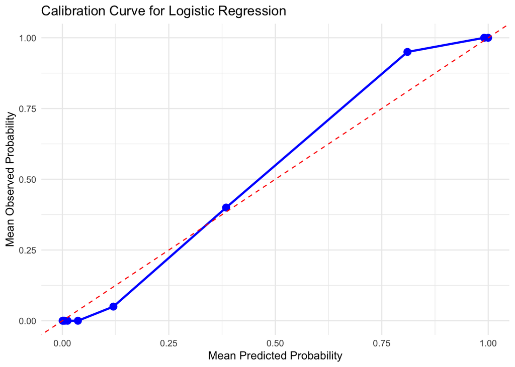

```r
# Logistic Model Manual Calibration Curve (Fixed Version)

# Step 1: Ensure status is numeric (convert if necessary)
test_data <- test_data %>%
  mutate(status = as.numeric(as.character(status)))  # Convert status to numeric if not already

# Step 2: Add predicted probabilities and bin into deciles
test_data <- test_data %>%
  mutate(predicted_prob = test_predictions) %>%  # Add predicted probabilities
  mutate(decile = ntile(predicted_prob, 10))  # Bin into 10 deciles

# Step 3: Calculate mean predicted and observed probabilities for each decile
library(dplyr)
calibration_data <- test_data %>%
  group_by(decile) %>%
  summarise(
    mean_predicted = mean(predicted_prob, na.rm = TRUE),  # Average predicted probability
    mean_observed = mean(status, na.rm = TRUE)  # Average observed status (0/1)
  )

# Step 4: Remove rows with NA (if any) from calibration data
calibration_data <- calibration_data %>%
  filter(!is.na(mean_predicted) & !is.na(mean_observed))

# Step 5: Plot calibration curve
library(ggplot2)
ggplot(calibration_data, aes(x = mean_predicted, y = mean_observed)) +
  geom_point(size = 3, color = "blue") +  # Points for observed vs predicted
  geom_line(color = "blue", size = 1) +   # Line connecting the points
  geom_abline(slope = 1, intercept = 0, linetype = "dashed", color = "red") +  # Perfect calibration line
  labs(
    x = "Mean Predicted Probability",
    y = "Mean Observed Probability",
    title = "Calibration Curve for Logistic Regression"
  ) +
  theme_minimal()
```

#### Step_7: Report Supplement and Results Summary

```r
# Descriptive Summary Table
summary_stats <- data_clean_no_outliers %>%
  summarise(
    Age = list(summary(age)),
    TumorSize = list(summary(tumor_size_log)),
    SurvivalMonths = list(summary(survival_months_boxcox)),
    NodeExamined = list(summary(regional_node_examined_log))
  )

knitr::kable(summary_stats, caption = "Summary Statistics for Key Variables")
```

Summary Statistics for Key Variables

| Age | TumorSize | SurvivalMonths | NodeExamined |
| --- | --- | --- | --- |
| 30.0000, 47.0000, 54.0000, 54.0677, 61.0000, 69.0000 | 0.6931472, 2.8332133, 3.2580965, 3.2482217, 3.6375862, 4.9487599 | 0.9333737, 12.3040417, 13.5665533, 13.2040930, 14.6847863, 15.5904935 | 0.6931472, 2.3025851, 2.7080502, 2.5623464, 2.9957323, 4.1271344 |

```r
# Model Results Summary Table
result_summary <- data.frame(
  Model = c("Logistic Regression", "Cox Proportional Hazards"),
  Train_AUC = c(auc_train, NA),
  Test_AUC = c(auc_test, auc_cox),
  Significant_Features = c(nrow(selected_variables_df), nrow(significant_coefficients))
)

knitr::kable(result_summary, caption = "Summary of Model Results")
```

Summary of Model Results

[output not shown]